# `phydms` Tutorial

In this tutorial you will learn the basics of `phydms`. We will walk through examples of analyses you may want to run to compare your deep mutational scanning data to natural sequence evolution. For more details on any of the steps, please see the [phydms documentation](http://jbloomlab.github.io/phydms/).

`phydms` was developed at the [Bloom Lab](http://research.fhcrc.org/bloom/en.html) ([full list of contributors](https://github.com/jbloomlab/phydms/graphs/contributors))

# Example Analyses

The examples used here come from [Bloom, Biology Direct, 12:1](http://biologydirect.biomedcentral.com/articles/10.1186/s13062-016-0172-z)

## Comparing your `DMS` data to natural sequence evolution

After you perform your deep mutational scanning experiment, you may want to know how well the experimental measurements you made in the lab describe the natural sequence evolution of your protein in nature. Using `phydms` you can compare the phylogenetic substitution model [*ExpCM*](https://academic.oup.com/mbe/article/31/10/2753/1015257/An-Experimentally-Informed-Evolutionary-Model), which takes into account the site-specific amino-acid preferences from your deep mutational scanning experiment, to traditional, non-site specific models from the [*YNGKP*](http://www.genetics.org/content/155/1/431) family. [`phydms_comprehensive`](http://jbloomlab.github.io/phydms/phydms_comprehensive_prog.html) will run `phydms` in several different modes to generate results for the appropriate comparisons.

For the standard `phydms_comprehensive` analysis, you will need amino-acid preferences from your deep mutational scanning experiment and a codon-level sequence alignment of your gene. `phydms_comprehensive` will then

• infer a tree using `RAxML`  
• run `phydms` with the *YNGKP_M0*, the *YNKGP_M5*, the *ExpCM*, and a control *ExpCM* run with averaged preferences  
• summarize the results

See the [full documentation](http://jbloomlab.github.io/phydms/index.html) for specifics on these models.

We are going to walk through an example of `phydms_comprehensive` and evaluation of how well the $\beta$-lactamase deep mutational scanning data from [Stiffler *et al*, 2015](http://www.sciencedirect.com/science/article/pii/S0092867415000781) describes natural sequence evolution.

### `phydms_comprehensive` command-line usage

Here is the full list of requirements and options for `phydms_comprehensive`. Below is a discussion of the input files, running the `phydms_comprehensive` command, and interpretation of the results.

```bash
phydms_comprehensive -h
```

```
usage: phydms_comprehensive [-h] (--raxml RAXML | --tree TREE) [--ncpus NCPUS] [--brlen {scale,optimize}] [--omegabysite] [--diffprefsbysite]
                            [--gammaomega] [--no-avgprefs] [--randprefs] [-v]
                            outprefix alignment prefsfiles [prefsfiles ...]

Comprehensive phylogenetic model comparison and detection of selection informed by deep mutational scanning data. This program runs 'phydms'
repeatedly to compare substitution models and detect selection. The 'phydms' package is written by the Bloom lab (see
https://github.com/jbloomlab/phydms/contributors). Version 2.0.dev0. Full documentation at http://jbloomlab.github.io/phydms

positional arguments:
  outprefix             Output file prefix.
  alignment             Existing FASTA file with aligned codon sequences.
  prefsfiles            Existing files with site-specific amino-acid preferences.

optional arguments:
  -h, --help            show this help message and exit
  --raxml RAXML         Path to RAxML (e.g., 'raxml') (default: None)
  --tree TREE           Existing Newick file giving input tree. (default: None)
  --ncpus NCPUS         Use this many CPUs; -1 means all available. (default: -1)
  --brlen {scale,optimize}
                        How to handle branch lengths: scale by single parameter or optimize each one (default: optimize)
  --omegabysite         Fit omega (dN/dS) for each site. (default: False)
  --diffprefsbysite     Fit differential preferences for each site. (default: False)
  --gammaomega          Fit ExpCM with gamma distributed omega. (default: False)
  --no-avgprefs         No fitting of models with preferences averaged across sites for ExpCM. (default: False)
  --randprefs           Include ExpCM models with randomized preferences. (default: False)
  -v, --version         show program's version number and exit
```

### Input Files

#### Amino-acid preferences

Often data from deep mutational scanning experiments is reported as the enrichment of a given amino-acid compared to the wild-type amino-acid. Here is a snippet of the log enrichment scores for $\beta$-lactamase from the file betaLactamase_enrichmentScores.csv in `example_data` and the full dataset visualized as a heatmap.

```r
library(ggplot2)
df = read.csv("example_data/betaLactamase_enrichmentScores.csv")
head(df,20)
```

```
   Site wildtype AminoAcid Trial_1_AmpConc_2500 Trial_2_AmpConc_2500.1
1    26        H         A         -0.003757501           -0.015809629
2    26        H         C         -0.319356518           -0.517163332
3    26        H         D         -0.155937758           -0.207275461
4    26        H         E         -0.200042482           -0.358005855
5    26        H         F         -0.493981846           -1.142992345
6    26        H         G         -0.043527004           -0.076956341
7    26        H         I         -0.292563068           -0.425819417
8    26        H         K          0.029525026           -0.000585873
9    26        H         L         -0.306059807           -0.654633344
10   26        H         M         -0.146503843           -0.303058742
11   26        H         N         -0.006558292           -0.079628033
12   26        H         P         -0.924415785           -1.097280491
13   26        H         Q         -0.084767134           -0.186369533
14   26        H         R         -0.008315397            0.003262881
15   26        H         S          0.068115045            0.004217149
16   26        H         T         -0.048731580           -0.085643512
17   26        H         V         -0.001619701           -0.052128393
18   26        H         W         -0.999196822           -1.695975099
19   26        H         Y         -0.588959987           -1.181090312
20   27        P         A         -1.430707001           -1.854483185
```

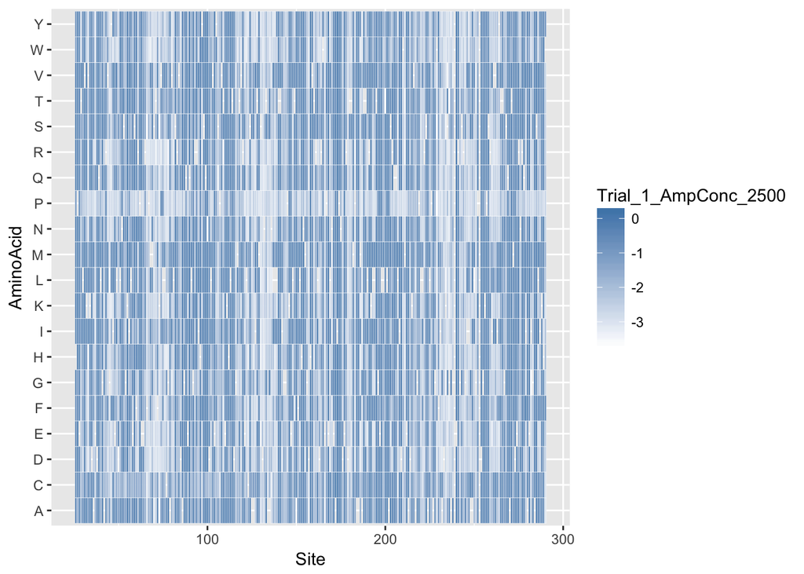

```r
p <- ggplot(df, aes(Site, AminoAcid)) + geom_tile(aes(fill = Trial_1_AmpConc_2500),colour = "white") + scale_fill_gradient(low = "white",high = "steelblue")
p
```

`phydms` uses *amino-acid preferences* rather than *enrichment scores*. We can transform these enrichment scores to amino-acid preferences by normalizing the values for each site. Below is the first few sites and amino-acids of the resulting preferences. Notice that the numbering has changed from above. In `phydms` a site is numbered in relation to the first site in the preferences rather than to the start codon.

```python
import pandas as pd
df = pd.read_csv("example_data/betaLactamase_enrichmentScores.csv")
minenrichment = 1.0e-4 # minimum allowed enrichment
df["preference"] = [max(minenrichment, 10**df["Trial_1_AmpConc_2500"][x] + 10**df["Trial_1_AmpConc_2500"][x]) for x in range(len(df))]
df = df.pivot(index = "Site", columns = "AminoAcid", values = "preference")
df.fillna(1, inplace = True)
df = df.div(df.sum(axis=1), axis=0)
df.insert(0, "site", range(1,len(df)+1))
df.to_csv("example_data/betaLactamase_prefs.csv", index = False)
print df.iloc[:,:9].head(20).to_string(index = False)
```

```
site         A         C         D         E         F         G         H         I

   1  0.072688  0.035145  0.051202  0.046257  0.023509  0.066328  0.036660  0.037382
   2  0.002116  0.036371  0.059299  0.080589  0.041568  0.012801  0.072947  0.051158
   3  0.059574  0.043571  0.051646  0.030585  0.049524  0.070819  0.064942  0.044508
   4  0.015988  0.004782  0.003708  0.003036  0.001518  0.002108  0.006938  0.207505
   5  0.069531  0.004496  0.000287  0.002933  0.028921  0.004126  0.026964  0.110570
   6  0.057646  0.049244  0.057585  0.071750  0.043926  0.055914  0.049790  0.048752
   7  0.130214  0.006118  0.000506  0.004339  0.000517  0.001098  0.029923  0.085763
   8  0.057005  0.251786  0.000225  0.000626  0.000292  0.000313  0.000146  0.265158
   9  0.081567  0.014785  0.000962  0.060540  0.023667  0.041009  0.076031  0.066652
  10  0.062312  0.050071  0.031783  0.060324  0.037893  0.047086  0.054284  0.052817
  11  0.094089  0.098171  0.000935  0.000786  0.041233  0.007026  0.001309  0.074653
  12  0.031217  0.003381  0.010548  0.527624  0.003123  0.010112  0.002974  0.001240
  13  0.053851  0.044167  0.025630  0.059220  0.047092  0.058216  0.050756  0.044407
  14  0.054632  0.049896  0.047887  0.056006  0.057122  0.052040  0.052886  0.057425
  15  0.012453  0.002613  0.006115  0.007336  0.083772  0.022495  0.020434  0.116012
  16  0.063706  0.016744  0.075331  0.073492  0.028370  0.037877  0.075709  0.026364
  17  0.137731  0.008867  0.002893  0.002248  0.002779  0.311667  0.001131  0.003646
  18  0.063025  0.002467  0.002578  0.001904  0.014750  0.001500  0.120099  0.046137
  19  0.004324  0.004764  0.000366  0.001398  0.198147  0.000601  0.000999  0.166347
  20  0.208842  0.006002  0.005040  0.005177  0.001574  0.698944  0.001971  0.001659
```

#### Sequences

We will use the alignment of $\beta$-lactamase sequences found in the `example_data` directory. It is important to note there is exactly the same number of preferences as sites in the alignment.

```
Sequences read from: example_data/betaLactamase_alignment.fasta
There are 85 sequences
Each sequence is 263 amino-acids long
Preferences read from: example_data/betaLactamase_prefs.csv
There are preferences measured for 263 sites
```

#### `phydms_comprehensive`

We can now run `phydms_comprehensive` by specifying our output prefix (in this case a directory), our preferences, and our alignment. The output below is the `phydms_comprehensive` run log.

```
phydms_comprehensive betaLactamase/ example_data/betaLactamase_alignment.fasta example_data/betaLactamase_prefs.csv
```

```bash
cat betaLactamase/log.log
```

```
2017-03-03 22:58:22,661 - INFO - Beginning execution of phydms_comprehensive in directory /Users/sarah/Google Drive/GS/lab/phydms/tutorial

2017-03-03 22:58:22,662 - INFO - Progress is being logged to betaLactamase/log.log

2017-03-03 22:58:22,662 - INFO - Version information:
    Time and date: Fri Mar  3 22:58:22 2017
    Platform: Darwin-15.6.0-x86_64-i386-64bit
    Python version: 3.5.2 (v3.5.2:4def2a2901a5, Jun 26 2016, 10:47:25)  [GCC 4.2.1 (Apple Inc. build 5666) (dot 3)]
    phydms version: 2.0.dev0
    Bio version: 1.68
    scipy version: 0.18.1
    matplotlib version: 2.0.0b4

2017-03-03 22:58:22,662 - INFO - Parsed the following command-line arguments:
    randprefs = False
    noavgprefs = False
    raxml = raxml
    alignment = example_data/betaLactamase_alignment.fasta
    omegabysite = False
    diffprefsbysite = False
    ncpus = -1
    tree = None
    outprefix = betaLactamase/
    prefsfiles = ['example_data/betaLactamase_prefs.csv']
    brlen = optimize
    gammaomega = False

2017-03-03 22:58:22,662 - INFO - Checking that the alignment example_data/betaLactamase_alignment.fasta is valid...
2017-03-03 22:58:23,094 - INFO - Valid alignment specifying 85 sequences of length 789.

2017-03-03 22:58:23,094 - INFO - Tree not specified.
2017-03-03 22:58:23,120 - INFO - Inferring tree with RAxML using command raxml
2017-03-03 22:58:31,759 - INFO - RAxML inferred tree is now named betaLactamase/RAxML_tree.newick
2017-03-03 22:58:31,761 - INFO - Removed the following existing files that have names that match the names of output files that will be created: betaLactamase/modelcomparison.md, betaLactamase/YNGKP_M5_log.log, betaLactamase/YNGKP_M5_tree.newick, betaLactamase/YNGKP_M5_loglikelihood.txt, betaLactama…

2017-03-03 22:58:31,761 - INFO - Starting analysis to optimize tree in betaLactamase/RAxML_tree.newick using model YNGKP_M5. The command is: phydms example_data/betaLactamase_alignment.fasta betaLactamase/RAxML_tree.newick YNGKP_M5 betaLactamase/YNGKP_M5 --brlen optimize --ncpus 1

2017-03-03 22:58:31,761 - INFO - Starting analysis to optimize tree in betaLactamase/RAxML_tree.newick using model ExpCM_betaLactamase_prefs. The command is: phydms example_data/betaLactamase_alignment.fasta betaLactamase/RAxML_tree.newick ExpCM_example_data/betaLactamase_prefs.csv betaLactamase/Exp…

2017-03-03 22:58:31,762 - INFO - Starting analysis to optimize tree in betaLactamase/RAxML_tree.newick using model averaged_ExpCM_betaLactamase_prefs. The command is: phydms example_data/betaLactamase_alignment.fasta betaLactamase/RAxML_tree.newick ExpCM_example_data/betaLactamase_prefs.csv betaLact…
```

[output cut: 17 more lines]

```
2017-03-03 23:51:56,029 - INFO - Analysis completed for averaged_ExpCM_betaLactamase_prefs
2017-03-03 23:51:56,046 - INFO - Found expected output file betaLactamase/averaged_ExpCM_betaLactamase_prefs_log.log
2017-03-03 23:51:56,046 - INFO - Found expected output file betaLactamase/averaged_ExpCM_betaLactamase_prefs_tree.newick
2017-03-03 23:51:56,047 - INFO - Found expected output file betaLactamase/averaged_ExpCM_betaLactamase_prefs_loglikelihood.txt
2017-03-03 23:51:56,047 - INFO - Found expected output file betaLactamase/averaged_ExpCM_betaLactamase_prefs_modelparams.txt
2017-03-03 23:51:56,051 - INFO - Analysis successful for averaged_ExpCM_betaLactamase_prefs

2017-03-04 00:10:49,239 - INFO - Analysis completed for YNGKP_M5
2017-03-04 00:10:49,242 - INFO - Found expected output file betaLactamase/YNGKP_M5_log.log
2017-03-04 00:10:49,242 - INFO - Found expected output file betaLactamase/YNGKP_M5_tree.newick
2017-03-04 00:10:49,242 - INFO - Found expected output file betaLactamase/YNGKP_M5_loglikelihood.txt
2017-03-04 00:10:49,242 - INFO - Found expected output file betaLactamase/YNGKP_M5_modelparams.txt
2017-03-04 00:10:49,243 - INFO - Analysis successful for YNGKP_M5

2017-03-04 00:10:50,319 - INFO - Successful completion of phydms_comprehensive
```

### Output files

`phydms_comprehensive` produces both the standard `phydms` output files for each model and a summary file.

```bash
ls betaLactamase/*
```

```
betaLactamase/ExpCM_betaLactamase_prefs_log.log
betaLactamase/ExpCM_betaLactamase_prefs_loglikelihood.txt
betaLactamase/ExpCM_betaLactamase_prefs_modelparams.txt
betaLactamase/ExpCM_betaLactamase_prefs_tree.newick
betaLactamase/RAxML_bestTree.betaLactamase_alignment
betaLactamase/RAxML_tree.newick
betaLactamase/YNGKP_M0_log.log
betaLactamase/YNGKP_M0_loglikelihood.txt
betaLactamase/YNGKP_M0_modelparams.txt
betaLactamase/YNGKP_M0_tree.newick
betaLactamase/YNGKP_M5_log.log
betaLactamase/YNGKP_M5_loglikelihood.txt
betaLactamase/YNGKP_M5_modelparams.txt
betaLactamase/YNGKP_M5_tree.newick
betaLactamase/averaged_ExpCM_betaLactamase_prefs_log.log
betaLactamase/averaged_ExpCM_betaLactamase_prefs_loglikelihood.txt
betaLactamase/averaged_ExpCM_betaLactamase_prefs_modelparams.txt
betaLactamase/averaged_ExpCM_betaLactamase_prefs_tree.newick
betaLactamase/log.log
betaLactamase/modelcomparison.md
```

### Interpretation of `phydms_comprehensive` results

To evaluate how well the $\beta$-lactamase deep mutational scanning data describe natural sequence evolution we can look at the summary file, `modelcomparison.md`.

| Model | deltaAIC | LogLikelihood | nParams | ParamValues |
| --- | --- | --- | --- | --- |
| ExpCM_betaLactamase_prefs | 0.00 | -3557.66 | 6 | beta=0.79, kappa=2.61, omega=0.51 |
| YNGKP_M5 | 350.80 | -3727.06 | 12 | alpha_omega=0.33, beta_omega=0.41, kappa=3.02 |
| averaged_ExpCM_betaLactamase_prefs | 475.92 | -3795.62 | 6 | beta=0.75, kappa=2.54, omega=0.35 |
| YNGKP_M0 | 507.68 | -3806.50 | 11 | kappa=2.57, omega=0.35 |

We can also evaluate the amino-acid preferences is by the value of the *ExpCM* stringency parameter, $\beta$. $\beta$ is a way to gauge how well the selection in the lab compares to selection in nature. When $\beta$ is fit to be greater than $1$ it means the selection in lab was not as strong as selection in nature. The converse is true when $\beta$ is less than $1$. In the $\beta$-lactamase example, $\beta$ is fit to be $0.79$. **Since this number is close to $1$, we can conclude that not only do the amino-acid preferences do a good job of describing the natural sequence evolution of $\beta$-lactamase but that the selection pressures exerted in lab closely match the selection pressures in nature.**

Using `phydms_comprehensive` we were able to conclude that the amino-acid preferences (normalized enrichment values) from a deep mutational experiment did a good job of describing the natural sequence evolution of $\beta$-lactamase.

Please see the [`phydms_comprehensive' full documentation](http://jbloomlab.github.io/phydms/phydms_comprehensive_prog.html) if you would like to learn more about the`phydms_comprehensive` program and its other options.

## Comparing two `DMS` dataset for the same protein

## Detecting Diversifying Selection